# Chapter5

Riku Turkki

2/23/2017

# Dimensionality reduction techniques — Data wrangling

```r
library(stringr)
library(dplyr)
library(data.table)
human <- read.table("http://s3.amazonaws.com/assets.datacamp.com/production/course_2218/datasets/human1.txt", sep  =",", header = T)
human$GNI <- str_replace(human$GNI, pattern = ",", replacement = "") %>% as.numeric()
keep <- c( "Country", "Edu2.FM", "Labo.FM", "Edu.Exp", "Life.Exp", "GNI", "Mat.Mor", "Ado.Birth", "Parli.F")
human <- select(human, one_of(keep))
human <- filter(human, complete.cases(human))
human <- human[1:155,]
rownames(human) <- human$Country
human <- select(human, -Country)
save(human, file = "human.Rda")
rm(list=ls())
```

# Dimensionality reduction techniques — Analysis

## point 1

```r
human <- read.table("~/Documents/github/IODS-project/human.txt", sep  =" ", header = T)
str(human)
```

```
## 'data.frame':    155 obs. of  8 variables:
##  $ Edu2.FM  : num  1.007 0.997 0.983 0.989 0.969 ...
##  $ Labo.FM  : num  0.891 0.819 0.825 0.884 0.829 ...
##  $ Edu.Exp  : num  17.5 20.2 15.8 18.7 17.9 16.5 18.6 16.5 15.9 19.2 ...
##  $ Life.Exp : num  81.6 82.4 83 80.2 81.6 80.9 80.9 79.1 82 81.8 ...
##  $ GNI      : int  64992 42261 56431 44025 45435 43919 39568 52947 42155 32689 ...
##  $ Mat.Mor  : int  4 6 6 5 6 7 9 28 11 8 ...
##  $ Ado.Birth: num  7.8 12.1 1.9 5.1 6.2 3.8 8.2 31 14.5 25.3 ...
##  $ Parli.F  : num  39.6 30.5 28.5 38 36.9 36.9 19.9 19.4 28.2 31.4 ...
```

The dataset *human* contains information regarding health, education, and govermental status collected from 155 countries. Short variable descriptions:

*Edu2.FM*: People with secondary education (female / male)

*Labo.FM*: Labour force participation rate (female / male)

*Edu.Exp*: Expected years of education

*Life.Exp*: Life expectancy at birth

*GNI*: Gross national income per capita

*Mat.Mor*: Maternal mortality ratio

*Ado.Birth*: Adolecent birth rate

*Parli.F*: Percent representation in parliament

For more detailed information please see: http://hdr.undp.org/sites/default/files/hdr2015_technical_notes.pdf

## point 2

```r
library(GGally)
```

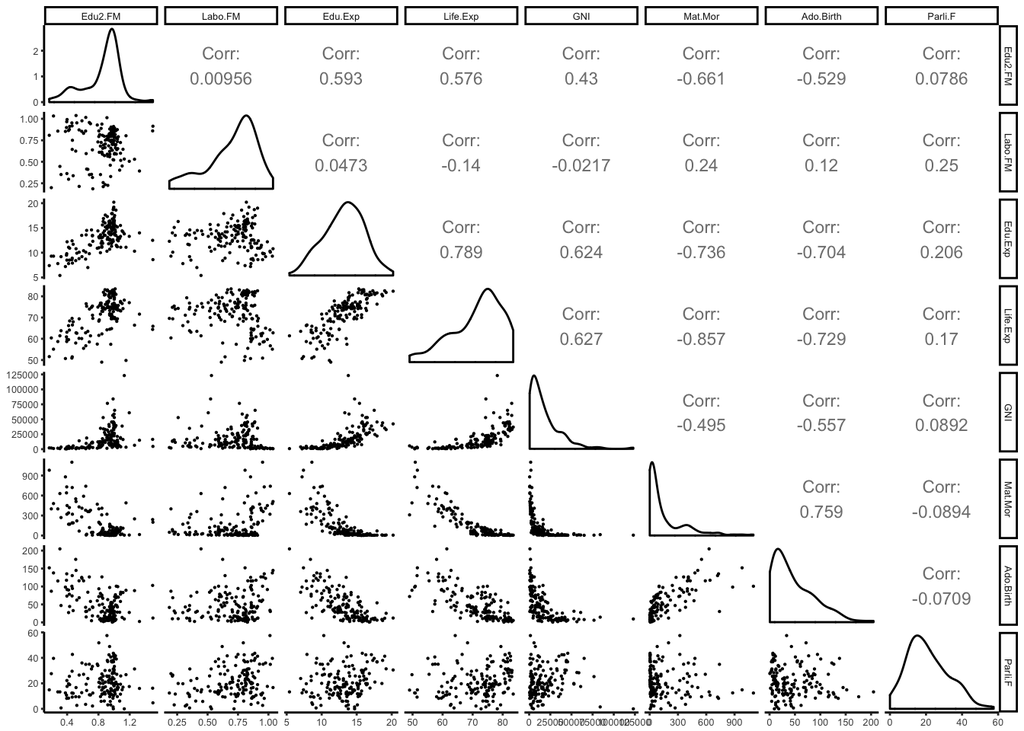

```r
library(ggplot2)

pm <- ggpairs(data = human,
              lower = list(continuous = wrap("points", size = .1)),
              upper = list(continuous = wrap("cor", size = 3)))
pm <- pm + theme_classic(base_size = 6)
pm
```

Brief comments on the data based on the plot above.

- Life expectancy has a strong correlations with education and strong negative correlation with maternal mortality and adolecent birth rate.
- Similarly GNI seem to correlate well with education and life expectancy. *Adolecent birth rate and maternal mortality are stronly linked.
- Interestingly percent precentation parliment doesn’t seem to correlate strongly with any of the variables.

## point 3

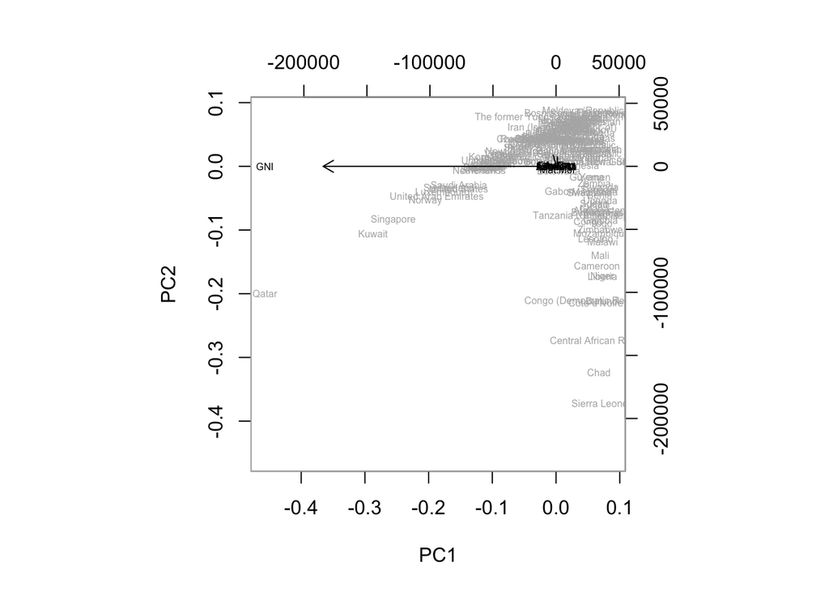

```r
pca_human <- prcomp(human)
biplot(pca_human, choices = 1:2, cex = c(0.5, 0.5), col = c("grey70", "black"))
```

Without scaling the above PCA biplot is dominated solely by GNI due to it’s large absolut values and variance.

## point 4

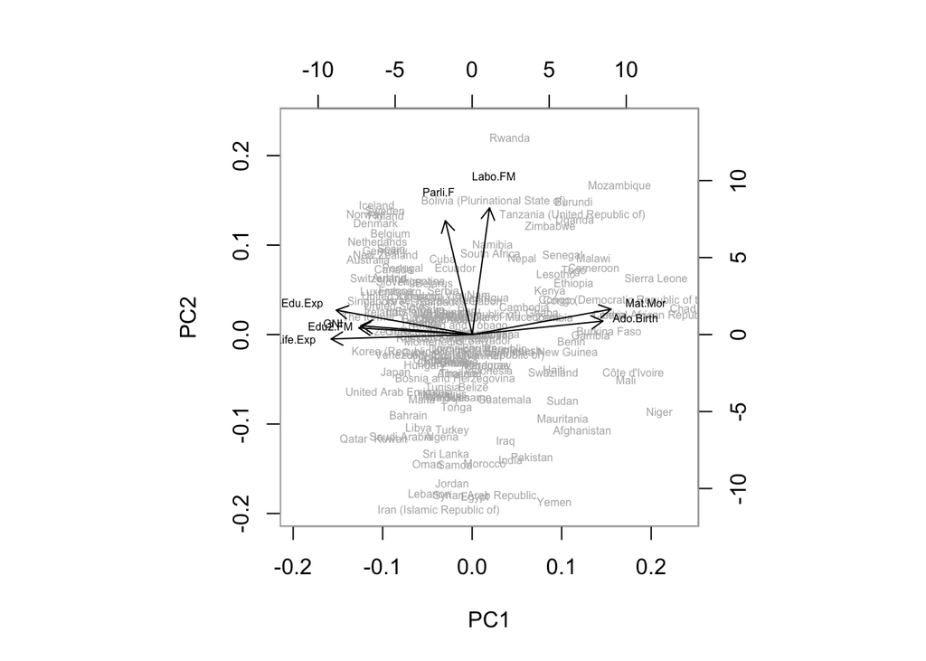

```r
human_norm <- scale(human)
pca_human_norm <- prcomp(human_norm)
biplot(pca_human_norm, choices = 1:2, cex = c(0.5, 0.5), col = c("grey70", "black"))
```

After normalizing the variables the underlying effect of individual variables can be seen from the biplot above more clearly.

## point 6

```r
rm(list = ls())
library(FactoMineR)
library(tidyr)
data(tea)
str(tea)
```

```
## 'data.frame':    300 obs. of  36 variables:
##  $ breakfast       : Factor w/ 2 levels "breakfast","Not.breakfast": 1 1 2 2 1 2 1 2 1 1 ...
##  $ tea.time        : Factor w/ 2 levels "Not.tea time",..: 1 1 2 1 1 1 2 2 2 1 ...
##  $ evening         : Factor w/ 2 levels "evening","Not.evening": 2 2 1 2 1 2 2 1 2 1 ...
##  $ lunch           : Factor w/ 2 levels "lunch","Not.lunch": 2 2 2 2 2 2 2 2 2 2 ...
##  $ dinner          : Factor w/ 2 levels "dinner","Not.dinner": 2 2 1 1 2 1 2 2 2 2 ...
##  $ always          : Factor w/ 2 levels "always","Not.always": 2 2 2 2 1 2 2 2 2 2 ...
##  $ home            : Factor w/ 2 levels "home","Not.home": 1 1 1 1 1 1 1 1 1 1 ...
##  $ work            : Factor w/ 2 levels "Not.work","work": 1 1 2 1 1 1 1 1 1 1 ...
##  $ tearoom         : Factor w/ 2 levels "Not.tearoom",..: 1 1 1 1 1 1 1 1 1 2 ...
##  $ friends         : Factor w/ 2 levels "friends","Not.friends": 2 2 1 2 2 2 1 2 2 2 ...
##  $ resto           : Factor w/ 2 levels "Not.resto","resto": 1 1 2 1 1 1 1 1 1 1 ...
##  $ pub             : Factor w/ 2 levels "Not.pub","pub": 1 1 1 1 1 1 1 1 1 1 ...
##  $ Tea             : Factor w/ 3 levels "black","Earl Grey",..: 1 1 2 2 2 2 2 1 2 1 ...
##  $ How             : Factor w/ 4 levels "alone","lemon",..: 1 3 1 1 1 1 1 3 3 1 ...
```

[output cut: 22 more lines]

```r
dim(tea)
```

```
## [1] 300  36
```

```r
summary(tea)
```

```
##          breakfast           tea.time          evening          lunch
##  breakfast    :144   Not.tea time:131   evening    :103   lunch    : 44
##  Not.breakfast:156   tea time    :169   Not.evening:197   Not.lunch:256
##
##
##
##
##
##         dinner           always          home           work
##  dinner    : 21   always    :103   home    :291   Not.work:213
##  Not.dinner:279   Not.always:197   Not.home:  9   work    : 87
##
##
##
##
##
##         tearoom           friends          resto          pub
##  Not.tearoom:242   friends    :196   Not.resto:221   Not.pub:237
##  tearoom    : 58   Not.friends:104   resto    : 79   pub    : 63
##
##
##
##
##
##         Tea         How           sugar                     how
##  black    : 74   alone:195   No.sugar:155   tea bag           :170
##  Earl Grey:193   lemon: 33   sugar   :145   tea bag+unpackaged: 94
##  green    : 33   milk : 63                  unpackaged        : 36
##                  other:  9
##
##
##
##                   where                 price          age        sex
##  chain store         :192   p_branded      : 95   Min.   :15.00   F:178
##  chain store+tea shop: 78   p_cheap        :  7   1st Qu.:23.00   M:122
##  tea shop            : 30   p_private label: 21   Median :32.00
##                             p_unknown      : 12   Mean   :37.05
##                             p_upscale      : 53   3rd Qu.:48.00
##                             p_variable     :112   Max.   :90.00
##
```

[output cut: 25 more lines]

```
##  feminine    :129   Not.sophisticated: 85   No.slimming:255
##  Not.feminine:171   sophisticated    :215   slimming   : 45
##
##
##
##
##
##         exciting          relaxing              effect.on.health
##  exciting   :116   No.relaxing:113   effect on health   : 66
##  No.exciting:184   relaxing   :187   No.effect on health:234
##
##
##
##
##
```

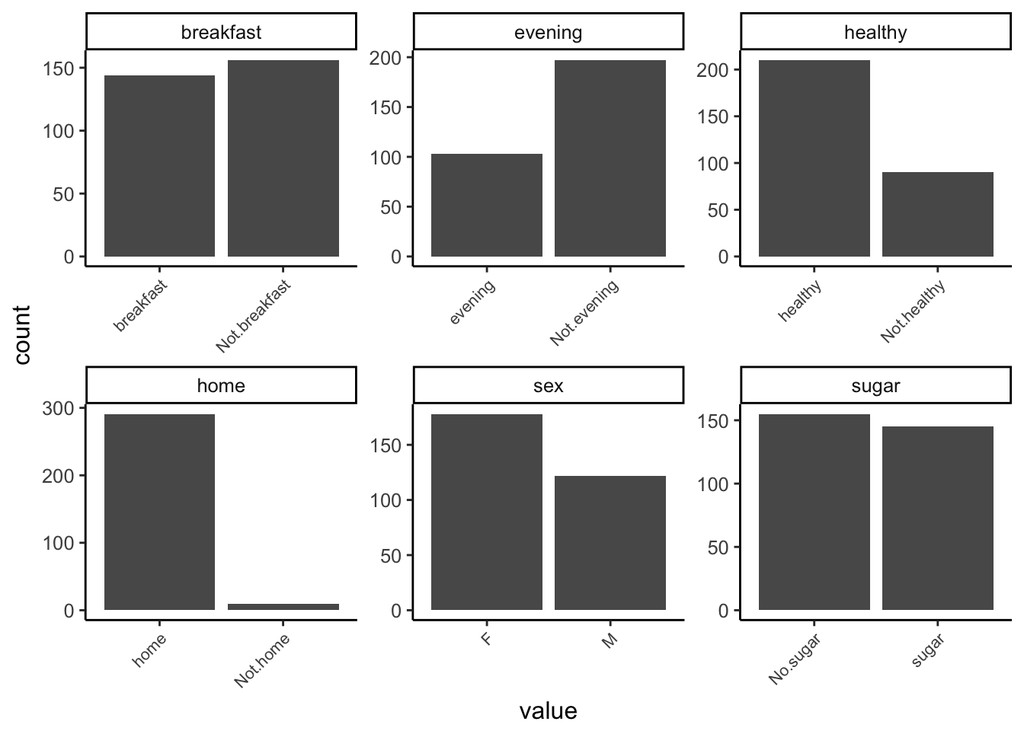

```r
keep = c("home", "evening", "breakfast", "sugar", "sex", "healthy")
tea <- select(tea, one_of(keep))
gather(tea) %>% ggplot(aes(value)) + geom_bar() + facet_wrap("key", scales = "free") + theme_classic(base_size = 12) + theme(axis.text.x = element_text(angle = 45, hjust = 1, size = 8))
```

```r
mca <- MCA(tea, graph = FALSE)
summary(mca)
```

```
##
## Call:
## MCA(X = tea, graph = FALSE)
##
##
## Eigenvalues
##                        Dim.1   Dim.2   Dim.3   Dim.4   Dim.5   Dim.6
## Variance               0.231   0.187   0.169   0.149   0.135   0.130
## % of var.             23.078  18.651  16.911  14.922  13.478  12.959
## Cumulative % of var.  23.078  41.729  58.641  73.563  87.041 100.000
##
## Individuals (the 10 first)
##                  Dim.1    ctr   cos2    Dim.2    ctr   cos2    Dim.3
## 1             |  0.011  0.000  0.000 | -0.841  1.265  0.925 |  0.186
## 2             | -0.738  0.787  0.886 | -0.012  0.000  0.000 |  0.131
## 3             | -0.121  0.021  0.018 |  0.562  0.565  0.386 | -0.328
## 4             |  0.314  0.143  0.134 | -0.366  0.240  0.182 |  0.291
## 5             |  0.252  0.091  0.049 | -0.157  0.044  0.019 | -0.621
## 6             | -0.118  0.020  0.020 | -0.051  0.005  0.004 |  0.269
## 7             | -0.422  0.257  0.239 | -0.526  0.495  0.372 |  0.164
## 8             | -0.121  0.021  0.018 |  0.562  0.565  0.386 | -0.328
## 9             | -0.062  0.006  0.004 | -0.256  0.117  0.062 | -0.057
## 10            | -0.108  0.017  0.012 | -0.427  0.326  0.187 | -0.400
##                  ctr   cos2
## 1              0.068  0.045 |
## 2              0.034  0.028 |
## 3              0.212  0.131 |
## 4              0.167  0.115 |
## 5              0.760  0.298 |
## 6              0.142  0.101 |
## 7              0.053  0.036 |
## 8              0.212  0.131 |
## 9              0.006  0.003 |
## 10             0.315  0.164 |
##
## Categories (the 10 first)
##                   Dim.1     ctr    cos2  v.test     Dim.2     ctr    cos2
## home          |  -0.078   0.422   0.195  -7.636 |  -0.030   0.076   0.028
## Not.home      |   2.511  13.660   0.195   7.636 |   0.956   2.448   0.028
## evening       |   0.594   8.761   0.185   7.432 |   0.169   0.871   0.015
```

[output cut: 12 more lines]

```
## breakfast     -10.634 |  -0.134   0.855   0.017  -2.234 |
## Not.breakfast  10.634 |   0.124   0.789   0.017   2.234 |
## No.sugar        7.057 |  -0.026   0.036   0.001  -0.472 |
## sugar          -7.057 |   0.028   0.038   0.001   0.472 |
## F              11.316 |  -0.033   0.064   0.002  -0.690 |
## M             -11.316 |   0.048   0.093   0.002   0.690 |
##
## Categorical variables (eta2)
##                 Dim.1 Dim.2 Dim.3
## home          | 0.195 0.028 0.497 |
## evening       | 0.185 0.015 0.437 |
## breakfast     | 0.191 0.378 0.017 |
## sugar         | 0.388 0.167 0.001 |
## sex           | 0.201 0.428 0.002 |
## healthy       | 0.225 0.103 0.062 |
```

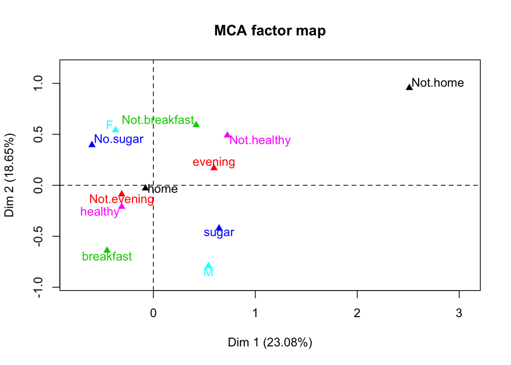

```r
plot(mca, invisible=c("ind"), habillage = "quali")
```

Comments on MCA analysis: * Based on the plot above it seems that males are drinking their tea with sugar more often than females. * For some reason variable *Not Home* is clearly separate from other variables (maybe because there’s only really few of those that are not drinking tea at home). * Another interesting note from the plot is that those who are healthy tend to drink tea more often during breakfast whereas those who are not healthy drink more often during evenings.